# PS 15 Section 2

### REMINDERS

1. KNIT AS YOU GO!
2. ALWAYS SET YOUR WORKING DIRECTORY FIRST
3. MAKE SURE YOU KNOW WHAT YOUR VARIABLES ARE (X and Y)
4. NEVER CODE IN THE CONSOLE
5. KEEP ANSWERS/QUESTIONS SEPARATE FOR EASY READING

### Load Data into R

House-keeping

```r
rm(list = ls())
# This command removes everything stored in your working memory.
```

**ALWAYS SET YOUR WORKING DIRECTORY FIRST!**

```r
setwd("/home/jovyan/UCSB_PS15/Section 2/")

# Remember to always check what your working directory is!
getwd()
```

```
## [1] "/home/jovyan/UCSB_PS15/Section 2"
```

There are several ways to load data, according to what type of file you have. Note: replace the capitalized words with the name of your file.

If you have csv data, use: `read.csv("YOUR_FILE.csv", header = T)`

If your data has a file extension .RData, use: `load("DATA.RData")`

Remember: now that you have loaded your data-set, you need to do stuff to it! The `summary()` command is a good way to check you have loaded your data-set in memory.

```r
schooldata <- read.csv("schooldata.csv", header = T)
summary(schooldata)
```

```
##      school         gender            math_score    language_score
##  Min.   :1.000   Length:316         Min.   : 0.50   Min.   :  0.20
##  1st Qu.:1.000   Class :character   1st Qu.:37.95   1st Qu.: 40.60
##  Median :1.000   Mode  :character   Median :49.15   Median : 50.05
##  Mean   :1.497                      Mean   :48.75   Mean   : 50.13
##  3rd Qu.:2.000                      3rd Qu.:60.90   3rd Qu.: 60.75
##  Max.   :2.000                      Max.   :99.80   Max.   :100.00
##     absences
##  Min.   : 0.00
##  1st Qu.: 1.00
##  Median : 3.00
##  Mean   : 5.81
##  3rd Qu.: 8.00
##  Max.   :45.00
```

### EXPLORE DATA

1. The number of rows (# of observations)

```r
nrow(schooldata)
```

```
## [1] 316
```

2. The number of columns (# of variables)

```r
ncol(schooldata)
```

```
## [1] 5
```

3. The dimension of dataset (*# of observations* tines *# of variables*)

```r
dim(schooldata)
```

```
## [1] 316   5
```

4. Assume that we are interested in `language score`. How can we access the variable `language_score` from the dataset?

```r
summary(schooldata$language_score)
```

```
##    Min. 1st Qu.  Median    Mean 3rd Qu.    Max.
##    0.20   40.60   50.05   50.13   60.75  100.00
```

```r
# Use $ operator to access variable
```

5. List all of the language scores

```r
list(schooldata$language_score)
```

```
## [[1]]
##   [1]  44.1  48.2  42.7  42.2  28.6  48.5  38.6  16.2  52.0  43.8  36.7  12.8
##  [13]  63.3  45.7  26.7  60.7  48.8  65.2  45.6   6.4  43.1  64.7  55.1  44.2
##  [25]  37.1  50.3   7.5  39.1  59.3  72.0  44.3  34.0  48.9  45.9  45.4  46.9
##  [37]  49.4  60.2   0.2  51.1  35.8  39.4  59.8  43.1   1.7  30.2  57.2  42.0
##  [49]  24.6  60.3  23.1  54.0  49.6  51.1  31.5  41.2  32.0  17.3  37.9  39.8
##  [61]  55.2  54.2  27.4  34.2  53.9  47.4  38.9  40.7  42.7  35.1  46.6  60.1
##  [73]  60.7  38.5  70.8  34.9  42.7  71.4  17.6  42.5  41.0  65.5  46.9  62.0
##  [85]  52.1  41.1  46.6  74.3  55.5  40.8  50.4  68.1  85.7  63.6   6.6  35.5
##  [97]  47.2  16.2  50.4  13.1  27.8  28.8  13.1  28.3  65.6  51.3   1.2  45.5
## [109]  39.0  60.0  36.2  40.3  39.1  19.4  66.3  34.6  41.7  24.9  75.5  40.6
## [121]  19.0  64.3  22.8  82.7  69.2  58.5   8.3  50.1  66.7  48.9  49.1  42.8
## [133]   6.4  38.0  38.2  36.0  50.3  62.9  45.4  36.2   9.1  34.8  55.3  31.8
## [145]  47.5  40.3  51.4  52.4  72.2  39.7  44.6  40.7  30.5  47.2  48.9  47.6
## [157]  29.9  34.2  42.7  50.1   2.7  39.1  63.5  53.9  71.2  59.5  48.9  55.1
## [169]  57.7  66.9  72.3  55.3  52.8  58.2  47.5  71.7  70.0  71.0  54.1  67.1
## [181]  50.0  64.3  28.8  51.1  71.0  63.3  60.2  41.6  68.7  77.6  42.7  53.4
## [193]  87.4  50.8  28.7  42.4  83.3  36.6  56.1  52.7  94.0  52.4  43.9  42.6
## [205]  63.5  47.3  44.5  72.3 100.0  45.6  61.9  56.8  78.3  57.7  48.6  61.4
## [217]  51.6  40.6  83.2  58.3  68.1  47.9  31.3  59.3  38.6  54.6  53.2  49.4
## [229]  57.1  49.9  68.9  74.9  58.4  88.1  66.7  57.1  64.8  49.7  73.6  36.7
## [241]  29.9  30.9  70.9  70.9  24.9  38.7  30.1  80.4  42.4  40.8  91.0  49.5
## [253]  53.1  54.1  56.0  53.0  65.7  68.2  43.6  53.9  42.3  46.5  71.8  69.5
## [265]  52.8  57.6  51.8  83.7  65.5  52.5 100.0  56.3  73.1  99.7  54.2  61.1
## [277]  34.8  43.9  41.0  60.9  58.9  48.4  61.5  66.2  50.9  59.2  64.4  60.0
## [289]  59.3  59.0  81.0  60.4  57.0  48.1  12.2  86.9  92.0  44.0  41.6  57.9
## [301]  69.2  46.2  60.3  58.8  47.3  61.9  15.8  53.8  43.1  72.3  71.9  49.0
## [313]  67.2  54.1  68.9  71.9
```

### EXERCISE

Now let’s practise!  
1. What is the minimum language score?  
2. What is the maximum language score?  
3. What is the range of the language scores?  
4. What is the average of the language scores?

```r
# PLEASE CODE HERE!
```

Hints: `min()` `max()` `range()` `mean()`

### GENERATE NEW VARIABLES

1. What is the difference between the language scores of the students and the math scores of the students?

```r
diff <- abs(schooldata$math_score - schooldata$language_score)
schooldata$difference <- abs(schooldata$math_score - schooldata$language_score)
# We can save our calculations to variables by assigning the result of our computations using the <- operator.
# We can also save that variable to our data-set by using the $ operator again.
# Question: what is the distinction between diff and schooldata$difference?
```

2. How big is that difference on average? What is the minimum and maximum of the difference?

```r
mean(schooldata$difference)
```

```
## [1] 10.81266
```

```r
min(schooldata$difference)
```

```
## [1] 0
```

```r
max(schooldata$difference)
```

```
## [1] 54.8
```

### EXPLORE CORRELATION

Let’s make a simple scatterplot with absences in the horizontal axis, and language scores on the vertical axis. Remember to always label your graphs!

Let’s estimate a regression (which looks at the relationship between variables), and then let’s add a regression line based on the linear regression model.

Remember, you are looking at the impact of the IV on the DV!

The independent variable (IV) can also be called the predictor variable or the explanatory variable. It is typically plotted on the X-axis (horizontal).

The dependent variable (DV) can also be called the response variable. It is typically plotted on the Y-axis (vertical).

Pay attention to the order in which you put your variables! The `plot()` command uses first X then Y. The `lm()` command uses first Y then X.

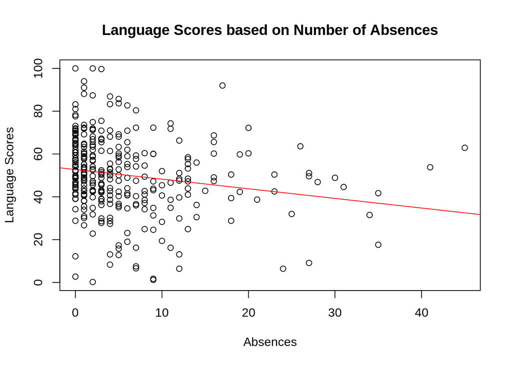

```r
plot(schooldata$absences, schooldata$language_score,
     ylab = "Language Scores",
     xlab = "Absences",
     main = "Language Scores based on Number of Absences")

model <- lm(schooldata$language_score ~ schooldata$absences,
            data = schooldata)

abline(model, col = "red")
```

```r
# What type of relationship is this?

# Print out the estimated coefficients:
summary(model)
```

```
##
## Call:
## lm(formula = schooldata$language_score ~ schooldata$absences,
##     data = schooldata)
##
## Residuals:
##     Min      1Q  Median      3Q     Max
## -51.642  -9.522   0.231  11.070  48.307
##
## Coefficients:
##                     Estimate Std. Error t value Pr(>|t|)
## (Intercept)          52.7419     1.2641  41.723  < 2e-16 ***
## schooldata$absences  -0.4497     0.1339  -3.358 0.000882 ***
## ---
## Signif. codes:  0 '***' 0.001 '**' 0.01 '*' 0.05 '.' 0.1 ' ' 1
##
## Residual standard error: 17.71 on 314 degrees of freedom
## Multiple R-squared:  0.03466,    Adjusted R-squared:  0.03159
## F-statistic: 11.27 on 1 and 314 DF,  p-value: 0.0008824
```

Now answer the following questions:  
1. What is the relationship between `absences` and `language_score`?  
2. What is the slope coefficient ($\beta_1$, pronounced “beta 1”) and the constant/intercept ($\beta_0$, pronounced “beta 0”)?

### EXERCISE

What is the relationship between `absences` and `math_score`?

What do you expect the relationship between `language_score` and `math_score` to be?

```r
# TYPE CODE HERE!
```

### LOAD RDATA

Let us now load data from the World Bank on CO$_2$ emissions and GDP per capita. Since the data-set has an .RData file extension, we need to use the command `load()`.

```r
load("worldbank.RData")
```

```r
head(worldbank)
```

```
##   country year CO2PerCapita GDPPerCapita
## 1   World 1960     3.099013     450.4803
## 2   World 1961     3.069727     462.2966
## 3   World 1962     3.140511     487.8821
## 4   World 1963     3.244499     514.5766
## 5   World 1964     3.360596     552.5011
## 6   World 1965     3.439099     589.4052
```

### PLOT DATA

We want to plot emissions of CO$_2$ per capita across time.

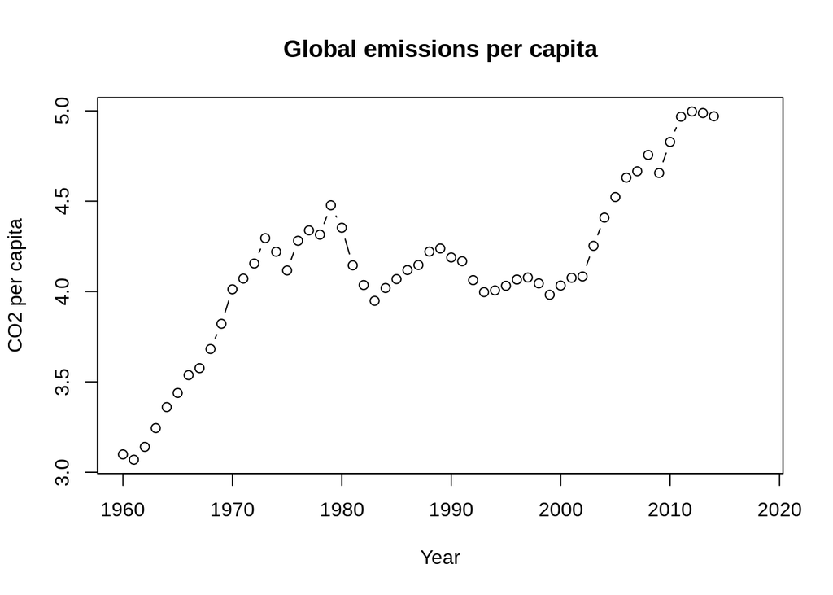

```r
plot(worldbank$year, worldbank$CO2PerCapita,
     type = "b",
     xlab = "Year",
     ylab = "CO2 per capita",
     main = "Global emissions per capita")
lines(worldbank$year, worldbank$GDPPerCapita)
```

```r
# The type = "b" option adds a line through the data-points.
```